# lab4_03117012

#### ΧΡΙΣΤΙΝΑ ΤΣΑΚΑΝΙΚΑ 03117012 ΣΗΜΜΥ 8ο ΕΞΑΜΗΝΟ

```python
import numpy as np
from numpy.random import choice
import statistics as stat
import matplotlib.pyplot as plt
%matplotlib inline
plt.rcParams['figure.figsize'] = (10, 6)  # default figure size
```

### Άσκηση 1

Απλός τυχαίος περίπατος, μέχρι αυτός να βγει από το διάστημα $[-70, 100].$

```python
np.random.seed(2017)  # same results are previous run

# random walk generator:
def rand_walk_Z(start, probs):
    x = start
    steps = [-1, 1]  # probs order should be (left, right)
    while True:  # continue for ever in needed
        x += choice(steps, p=probs)
        yield x  # it's a generator!
```

- 500 διαδρομές με τάση προς τα αριστερά $p(k, k+1) = \frac{1}{5}, p(k,k-1) = \frac{4}{5}$

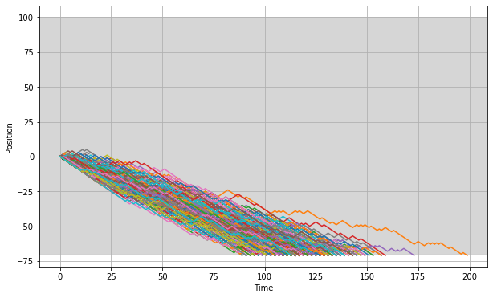

```python
fig, ax = plt.subplots()  # initiate plots

a = -70  # lower boundary
b = 100  # upper boundary
left = []
left_time = np.zeros(500, dtype=int)

for col in range(500):  # 500 random walks r-ed, g-reen, b-lue
    walker = rand_walk_Z(start=0,probs=(4/5, 1/5))  # start new symmetric walk from 0
    x = 0  # start position 0
    chain = [x]  # save positions to plot
    time = 0
    while a <= x <= b:
        x = next(walker)
        time +=1
        chain.append(x)
    ax.plot(chain)
    left.append(chain)
    left_time[col] = time

# To look nicer
plt.axhspan(a, b, color = '#cccccc', alpha = 0.8)  # box between a & b
ax.grid()  # adds grid lines
plt.xlabel('Time')
plt.ylabel('Position')

# Show image!
plt.show()
```

- 500 διαδρομές με τάση προς τα δεξιά $p(k, k+1) = \frac{4}{5}, p(k,k-1) = \frac{1}{5}$

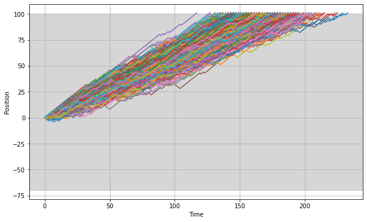

```python
fig, ax = plt.subplots()  # initiate plots
a = -70  # lower boundary
b = 100  # upper boundary
right = []
right_time = np.zeros(500, dtype=int)

for col in range(500):  # 500 random walks
    walker = rand_walk_Z(start=0,probs=(1/5, 4/5))  # start new  walk from 0
    x = 0  # start position 0
    chain = [x]  # save positions to plot
    time=0
    while a <= x <= b:
        x = next(walker)
        time +=1
        chain.append(x)
    ax.plot(chain)
    right.append(chain)
    right_time[col] = time
# To look nicer
plt.axhspan(a, b, color = '#cccccc', alpha = 0.8)  # box between a & b
ax.grid()  # adds grid lines
plt.xlabel('Time')
plt.ylabel('Position')

# Show image!
plt.show()
```

### Ερώτηση 1:

Σχεδιασμός των 1000 διαδρομών σε ένα κοινό διάγραμμα. Αποδίδουμε με κόκκινο αυτές που έχουν τάση προς τα αριστερά και αυτές που έχουν τάση προς τα δεξιά με μπλε.

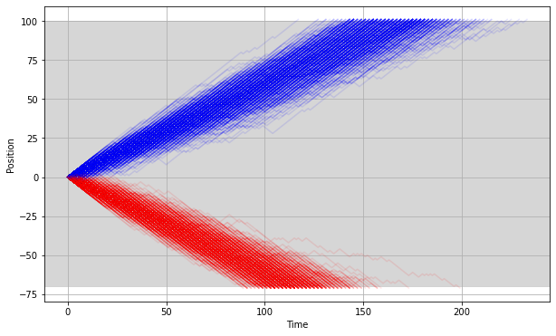

```python
fig, ax = plt.subplots()  # initiate plots
for i in range(500):
    ax.plot(left[i],color="red", alpha=0.1)
    ax.plot(right[i],color="blue", alpha=0.1)

plt.axhspan(a, b, color = '#cccccc', alpha = 0.8)  # box between a & b
ax.grid()  # adds grid lines
plt.xlabel('Time')
plt.ylabel('Position')

# Show image!
plt.show()
```

### Ερώτηση 2:

- Σχεδιασμός ιστογράμματος των χρόνων εξόδου για τις δύο περιπτώσεις σε κοινό γράφημα.
- Το ιστόγραμμα που αντιστοιχεί στην αλυσίδα με τάση δεξιά να είναι μπλέ και το άλλο κόκκινο.

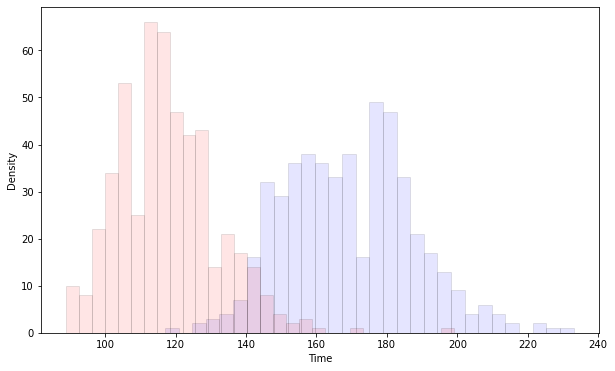

```python
plt.hist(right_time, bins=30, color='blue', edgecolor='black', alpha=0.1)
plt.hist(left_time, bins=30, color='red', edgecolor='black', alpha=0.1)
plt.xlabel('Time')
plt.ylabel('Density')
plt.show()
```

## Άσκηση 2:

Δημιουργούμε μία αλυσίδα που να κινείται στον $\mathbb{Z}_+$ με πιθανότητες μετάβασης:

- Για $k > 0$: $p(k, k+1) = \frac{1}{3}$ και $p(k, k-1) = \frac{2}{3}$
- Για $k = 0$: $p(0, 1) = \frac{1}{3}$ και $p(0, 0) = \frac{2}{3}$

Προσομοιώνουμε την αλυσίδα `1000` φορές.

```python
np.random.seed(2017)  # same results are previous run

# random walk generator:
def rand_walk_Z_plus(start, probs):
    x = start
    steps = [0, 1]  # probs order should be (left, right)
    while True:  # continue for ever in needed
        x += choice(steps, p=probs)
        yield x  # it's a generator!
```

```python
M1000 = np.zeros(1000, dtype=int)
X100 = np.zeros(1000, dtype=int)

for i in range(1000):
    walker1 = rand_walk_Z(start=0,probs=(2/3, 1/3))  # start new  walk from 0
    walker2 = rand_walk_Z_plus(start=0,probs=(2/3, 1/3))
    x = 0
    time=0
    while time<=1000:
        Xk[time].append(x)
        if x ==0:
            x = next(walker2)
            if x > M1000[i]:
                M1000[i] = x
        else:
            walker1 = rand_walk_Z(start=x,probs=(2/3, 1/3))
            x = next(walker1)
            if x > M1000[i]:
                M1000[i] = x
        if time == 100:
            X100[i] = x
        time +=1
```

### Ερώτηση 1:

Σχεδιάzουμε το ιστόγραμμα της θέσης $x_{100}$ όπου βρίσκεται η αλυσίδα μετά το εκατοστό βήμα της.

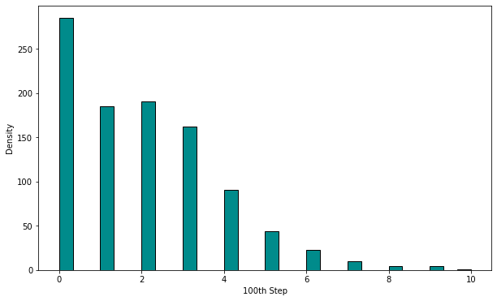

```python
fig, ax = plt.subplots()  # initiate plots
plt.hist(X100, bins=30, color='darkcyan', edgecolor='black')
plt.xlabel('100th Step')
plt.ylabel('Density')
plt.show()
```

### Ερώτηση 2:

$$ M_n = \max_{0\le k\le n} X_k$$

η δεξιότερη θέση που φτάνει η αλυσίδα στα $n$ πρώτα της βήματα.

1. Iστόγραμμα της κατανομής της $M_{1000}$

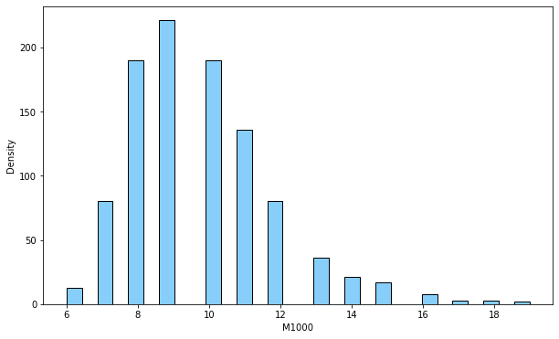

```python
fig, ax = plt.subplots()  # initiate plots
plt.hist(M1000, bins=30, color='lightskyblue', edgecolor='black')
plt.xlabel('M1000')
plt.ylabel('Density')
plt.show()
```

1. Υπολογισμός της δειγματικής μέσης τιμής και διασποράς της.

```python
print('The sample mean of the max position is',stat.mean(Mn),'and the sample variance is',stat.variance(Mn))
```

[output not shown]

## Άσκηση 3

```python
# random walk in Z^2 generator:
def rand_walk_Z2(start=(0, 0), probs=(0.25, 0.25, 0.25, 0.25)):
    # probs order (left, right, bottom, up)
    x, y = start
    steps = [(-1, 0), (1, 0), (0, -1), (0, 1)]
    while True:
        dx, dy = steps[choice(4, p=probs)]  # choice(4) = choose a number in [0,3]
        x, y = x + dx, y + dy
        yield x, y
```

```python
R = np.arange(10,110,10)  # radius of circle boundary
R2 = R**2  # square of radius

N = 500  # sample size
escape = []
for i in R2:
    escape_time = np.zeros(N, dtype=int)  # to store the exit time
    for n in range(N):
        walker = rand_walk_Z2()
        x, y = (0, 0)
        time = 0
        while x**2 + y**2 < i:
            x, y = next(walker)
            time += 1
        escape_time[n] = time
    escape.append(escape_time)
```

```python
mean_escape = []
for i in range(len(R)):
    print("Mean escape time for rad " + str(R[i]) + " is " + str(stat.mean(escape[i])))
    mean_escape.append(stat.mean(escape[i]))
```

```
Mean escape time for rad 10 is 111
Mean escape time for rad 20 is 411
Mean escape time for rad 30 is 911
Mean escape time for rad 40 is 1574
Mean escape time for rad 50 is 2515
Mean escape time for rad 60 is 3675
Mean escape time for rad 70 is 4980
Mean escape time for rad 80 is 6787
Mean escape time for rad 90 is 8194
Mean escape time for rad 100 is 10189
```

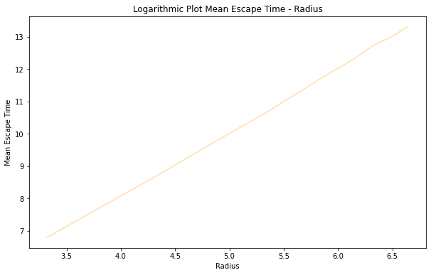

```python
x = np.log2(R)
y = np.log2(mean_escape)

plt.figure()
plt.plot(x, y, color = 'navajowhite')
plt.xlabel('Radius')
plt.ylabel('Mean Escape Time')
plt.title('Logarithmic Plot Mean Escape Time - Radius')
```

Υπολογίζουμε την κλίση της παραπάνω ευθείας

```python
 np.polyfit(x, y, 1)[0]
```

```
1.9765994428802713
```

Η τιμή αυτή είναι πάρα πολύ κοντά στο 2, συνεπώς διαπιστώνουμε, πως ο χρόνος εξόδου ισούται με το τετράγωνο της ακτίνας. Πράγματι, η γραφική παράσταση παρουσιάζει ότι οι τιμές του Mean Escape Time είναι οι διπλάσιες του Radius